# Roger Federer

Angelo

2023-10-29

```r
library(readr)
g <- read_csv("C:/Users/redbu/Downloads/g.csv")
g=g[,-c(1,6,10)]
g = g %>%
  mutate(result=ifelse(result=="l","Lose","Win"),
         tourney_level=recode(tourney_level, "A"="Others", "M"="Masters", "G"="Grand Slams", "F"="Others"))
```

```r
g=g %>%
  na.omit()
glimpse(g)
```

```
## Rows: 1,300
## Columns: 19
## $ tourney_name  <chr> "Dubai", "Roland Garros", "Wimbledon", "Australian Open"…
## $ surface       <chr> "Hard", "Clay", "Grass", "Hard", "Hard", "Clay", "Hard",…
## $ tourney_level <chr> "Others", "Grand Slams", "Grand Slams", "Grand Slams", "…
## $ tourney_date  <date> 2011-02-21, 2011-05-22, 2011-06-20, 2011-01-17, 2011-08…
## $ result        <chr> "Lose", "Lose", "Lose", "Lose", "Lose", "Lose", "Lose", …
## $ opponent      <chr> "Novak Djokovic", "Rafael Nadal", "Jo-Wilfried Tsonga", …
## $ seed          <dbl> 1, 3, 3, 2, 3, 2, 3, 3, 3, 3, 3, 2, 3, 3, 1, 3, 1, 3, 1,…
## $ hand          <chr> "R", "R", "R", "R", "R", "R", "R", "R", "R", "R", "R", "…
## $ ioc           <chr> "SUI", "SUI", "SUI", "SUI", "SUI", "SUI", "SUI", "SUI", …
## $ age           <dbl> 29.53867, 29.78782, 29.86448, 29.44285, 30.05613, 29.672…
## $ aces          <dbl> 5, 11, 17, 5, 11, 2, 6, 0, 8, 10, 11, 1, 16, 5, 9, 1, 7,…
## $ `_1stIn`      <dbl> 35, 80, 103, 62, 101, 44, 35, 63, 59, 58, 53, 48, 98, 57…
## $ `_1stWon`     <dbl> 22, 55, 80, 45, 68, 29, 20, 41, 49, 43, 40, 33, 80, 35, …
## $ `_2ndWon`     <dbl> 9, 18, 24, 20, 35, 11, 11, 16, 19, 16, 7, 15, 32, 21, 17…
## $ bpFaced       <dbl> 10, 15, 9, 14, 12, 5, 5, 12, 3, 9, 7, 10, 8, 9, 5, 12, 3…
## $ bpSaved       <dbl> 6, 8, 6, 9, 6, 3, 1, 7, 1, 7, 5, 5, 5, 4, 2, 7, 2, 3, 3,…
## $ df            <dbl> 1, 1, 1, 0, 4, 0, 1, 1, 2, 2, 2, 2, 5, 1, 2, 4, 2, 1, 3,…
## $ SvGms         <dbl> 9, 21, 26, 17, 25, 10, 9, 14, 17, 14, 10, 13, 26, 16, 16…
## $ svpt          <dbl> 58, 126, 137, 105, 164, 66, 58, 103, 93, 93, 81, 85, 160…
```

The dataset has been extracted by Tennis Data Portal (https://count.co/report/g1YaWINtnZL?frame=oQfcfwXW3Ip) and it contains 1525 individuals and 22 features related to Roger Federer’s performance, one of the greatest tennis player ever. After some data trasformation and putting out some unuseful columns, we can start our analysis concentrating in first sight to aces.

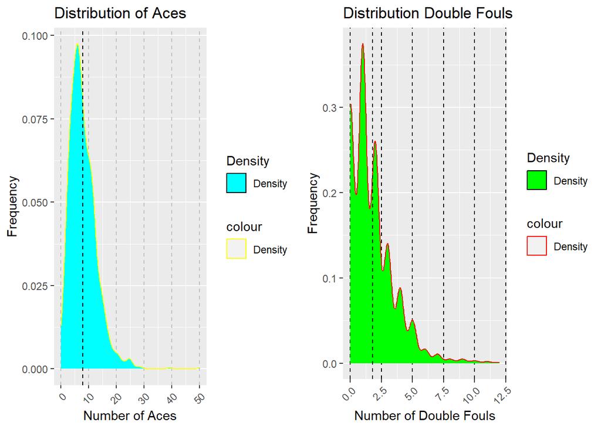

```r
graph1 = ggplot(data = g, mapping = aes(x = aces)) +
  geom_density(aes(fill = "Density", color = "Density"))+
  geom_vline(mapping=aes(fill="white"),xintercept = mean(g$aces), linetype = "dashed")+
  xlab("Number of Aces") +
  ylab("Frequency") +
  ggtitle("Distribution of Aces") +
  scale_fill_manual(values = c("Density" = "cyan")) +
  scale_color_manual(values = c("Density" = "yellow")) +
  guides(fill = guide_legend(title = "Density"))+
  theme(axis.text.x = element_text(angle = 45, hjust = 1))+
  theme(panel.grid.major.x = element_line(colour = "gray", linetype = "dashed"))
graph2 = ggplot(data = g, mapping = aes(x = df)) +
  geom_density(aes(fill = "Density", color = "Density"))+
  geom_vline(mapping=aes(fill="white"),xintercept = mean(g$df), linetype = "dashed")+
  xlab("Number of Double Fouls") +
  ylab("Frequency") +
  ggtitle("Distribution Double Fouls") +
  scale_fill_manual(values = c("Density" = "green")) +
  scale_color_manual(values = c("Density" = "red")) +
  guides(fill = guide_legend(title = "Density"))+
  theme(axis.text.x = element_text(angle = 45, hjust = 1))+
  theme(panel.grid.major.x = element_line(colour = "black", linetype = "dashed"))
subplot1 <- grid.arrange(graph1, graph2, ncol = 2)
```

```r
print(subplot1)
```

The comparison between aces’ distribution and double fouls’ distribution shows a great difference because the first is a unimodal distribution with a mean near 10, with a peak of 50 aces per game which is unbelievable, the second is a multimodal distribution with a mean of 2 double fouls per game.

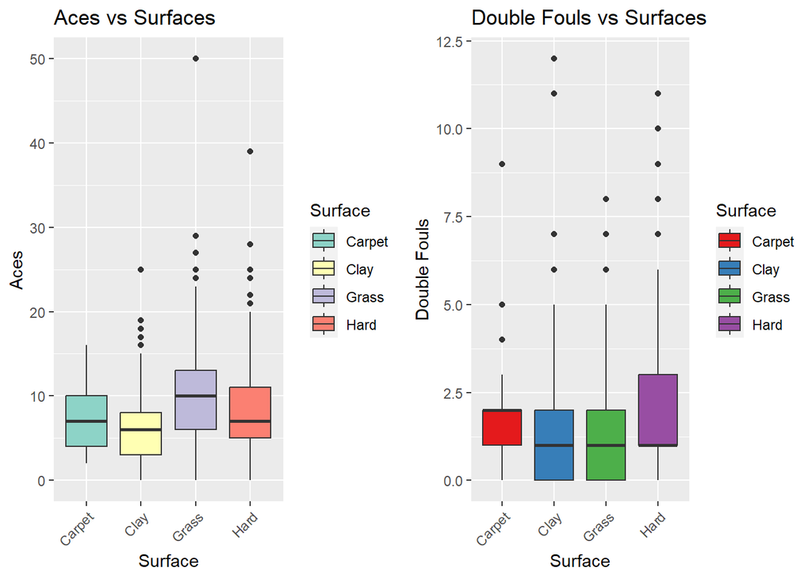

```r
graph3 = ggplot(data = g, mapping = aes(x = surface, y = aces)) +
  geom_boxplot(aes(fill = surface)) +
  xlab("Surface") +
  ylab("Aces") +
  ggtitle("Aces vs Surfaces") +
  scale_fill_brewer(palette = "Set3")+
  guides(fill = guide_legend(title = "Surface"))+
  theme(axis.text.x = element_text(angle = 45, hjust = 1))

graph4 = ggplot(data = g, mapping = aes(x = surface, y = df)) +
  geom_boxplot(aes(fill = surface)) +
  xlab("Surface") +
  ylab("Double Fouls") +
  ggtitle("Double Fouls vs Surfaces") +
  scale_fill_brewer(palette = "Set1")+
  guides(fill = guide_legend(title = "Surface"))+
  theme(axis.text.x = element_text(angle = 45, hjust = 1))

subplot2 = grid.arrange(graph3, graph4, ncol = 2)
```